# Categorical Statistics Final Project

# Problem 1: Socioeconomic Class Dataset

## Introduction

We analyzed the Socioeconomic Class Data, `student.csv`, which contained the following columns:

Column 1: `gender`: With values `female` and `male`.

Column 2: `schtyp`: School type, with values `public, private`.

Column 3: `read`: The reading score of a standardized test.

Column 4: `write`: The writing score of a standardized test.

Column 5: `math`: The math score of a standardized test.

Column 6: `science`: The science score of a standardized test.

Column 7: `honors`: Whether or not the student is enrolled in an honors class, with values `no, yes`.

Column 8: `ses`: Socioeconomic classs

## Summary

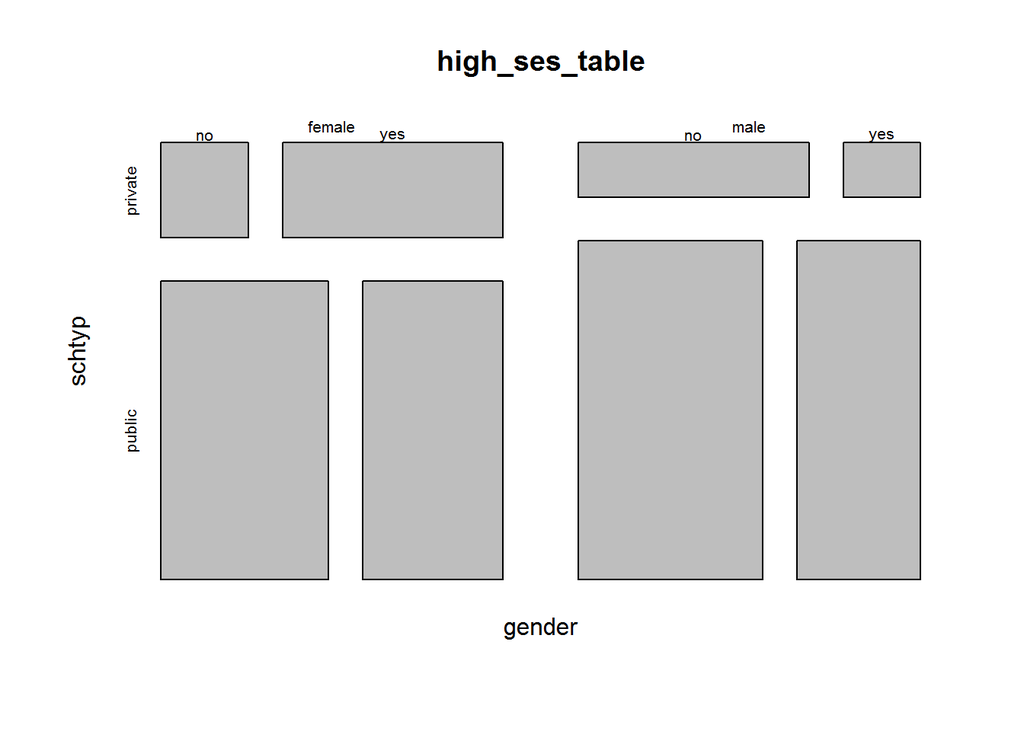

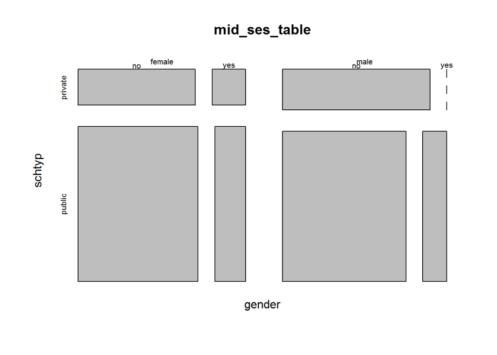

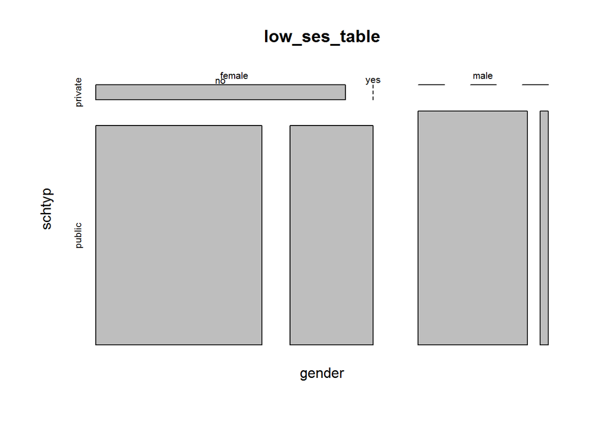

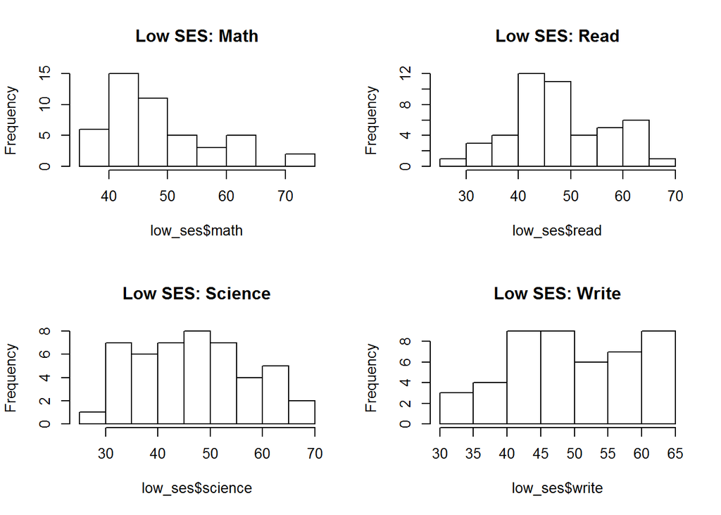

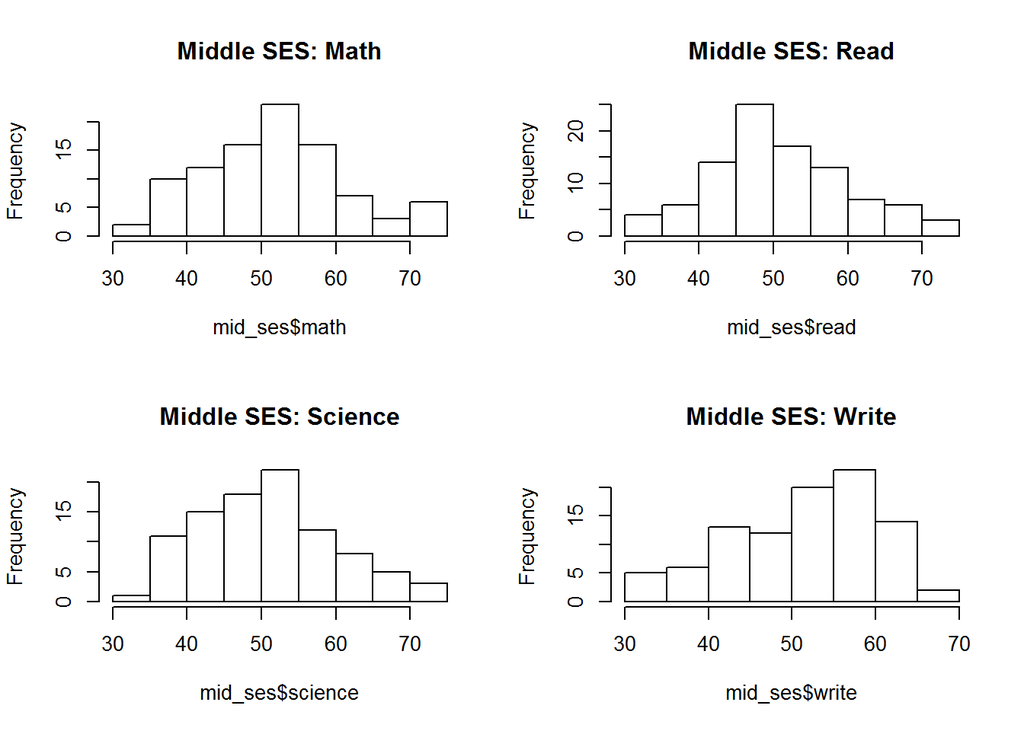

For all subjects, students in middle ses score within a range of 30 to 75.

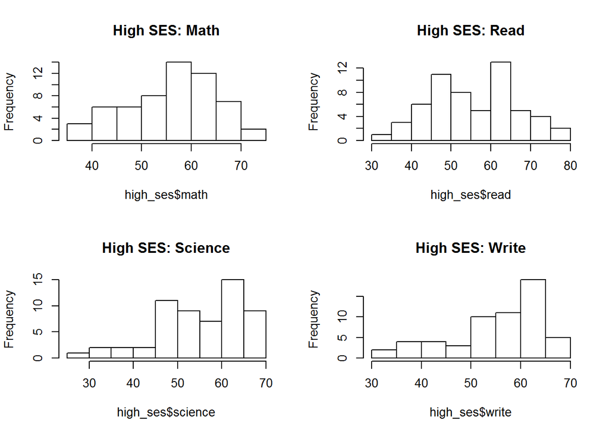

## Analysis

We used an AIC, backward-forward selection because we want to do prediction later. We chose this type of selection because backward selection overfits, but backward-forward overfits a little bit less and we chose it AIC because it penalizes less than BIC.

Based on the criterion, our best fit model is: ses ~ gender + schtyp + read + honors with an AIC of 403.7529. Below are the estimated coefficents for the selected variables:

Low vs high: $log_{IT}(\pi) = 2.644419 + (-0.8675304)X^{\text{gender}}_{1} + 1.6367326X^{\text{schtyp}}_{2} + (-0.07403496)X^{\text{read}}_{3} + (-0.2937044)X^{\text{honors}}_{4}$

Middle vs high: $log_{IT}(\pi) = 2.304598 + (-0.1910837)X^{\text{gender}}_{1} + 0.0462631^{\text{schtyp}}_{2} + (-0.02470590)X^{\text{read}}_{3} + (-1.1706580)X^{\text{honors}}_{4}$

There is only two models because it is redundent to have the third model since we can solve for third model, low vs middle, by subtracting middle vs high from low vs high.

### Diagnostics

Our next step was to split the data based on the ses into two groups: low vs high and middle vs high, and then find the logicistic models for each group.

The is logistic regression models for low vs high: $2.32625 + (-0.92733)X^{gender:male}_{1} + 1.80442X^{schtyp:piblic}_{2} + (-0.07004)X^{read}_{3} + (-0.32266)X^{honor:yes}_{4}$

The is logistic regression models for medium vs high: $2.29402 + (-0.14854)X^{gender:male}_{1} + (-0.07580)X^{schtyp:piblic}_{2} + (-0.02458)X^{read}_{3} + (-1.15141)X^{honor:yes}_{4}$

We found the outliers and potential influencial points for each of our split models.

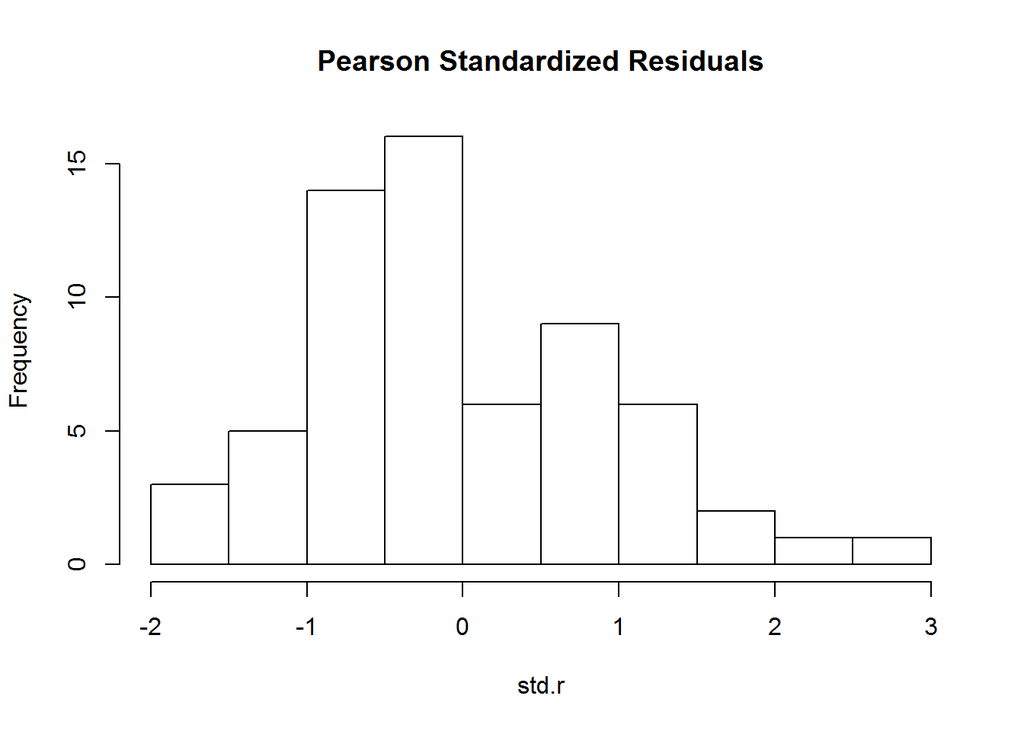

From the histogram plot above, we can see that most of our residuals for our low vs high model are normal. We can see that none of our residuals are greater than |3| and so there may not be outliers/influential points.

To check if there were, we calcualted the change in Pearson Chi-Squared for each observation. When the change is large, it generally means that the observation we added may be an outlier or an influential point. We found one change in Pearson’s Chi-Squared that was larger than 6(our cutoff value): a female, private school student, with a reading score of 60, who was not in honors.

```
##    (Intercept) gendermale schtyppublic read honorsyes   dChisq
## 1:           1          0            0   60         0 7.206981
```

We did the same thing for our middle vs high model and found:

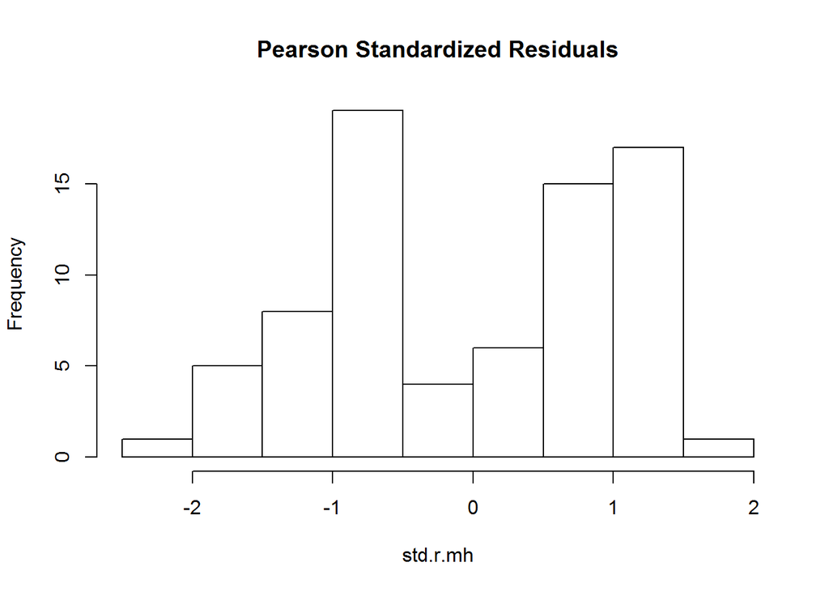

From our histogram plot of our middle vs high model, we can see that there is not any residuals greater than |3|, which means we probably do not have any outliers or influentials points. To double check we ran the change in Pearson Chi-Squared and found no changes greater than our cutoff value of 6.

```
## Empty data.table (0 rows) of 6 cols: (Intercept),gendermale,schtyppublic,read,honorsyes,dChisq
```

We also found the predictive power assessment for each of the split models.

Our predictive power based on proportional redunction in squared error for our low vs high model is 0.2099446. For the middle vs high model, our predictive power based on proportional redunction in squared error is 0.1049546.

We also solved for the AUC for each of our models to determine our goodness of fit.

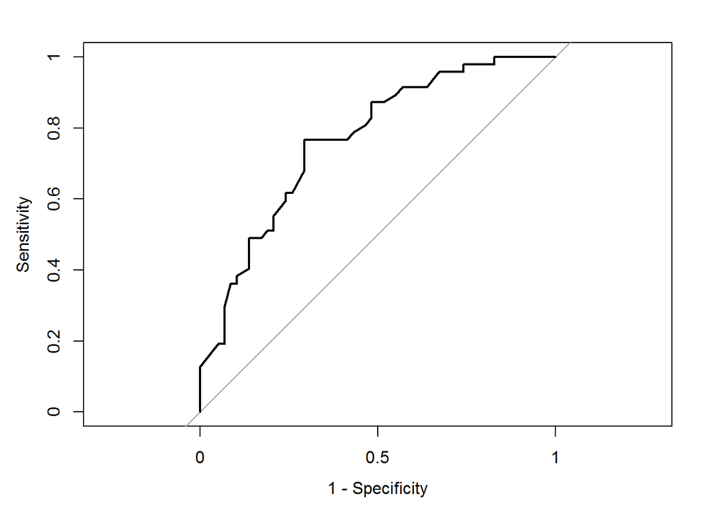

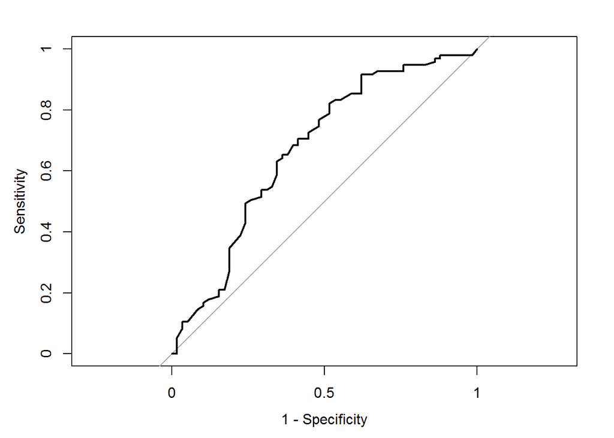

The AUC for low vs high is 0.766 with a 95% confidence interval (0.676,0.8559). And the AUC for middle vs high is 0.6712 with a 95% confidence interval (0.5791,0.7634).

Lastly, We found the error matrix for the multinomial model that we fit before we split up our model:

```
##         preds
## actual   high low middle
##   high     24   3     31
##   low       7  11     29
##   middle   15   5     75
```

And the error percentage is 45%

We predicted the probability for female, who scored 60 on all her tests, who went to private school, and who was not in the honors program for each ses:

```
##       high        low     middle
## 0.29058933 0.04814572 0.66126495
```

## Interpretation

Both AUCs are greater than 0.5, the equivalent of a coin flip, we can say that both of our model fit relavatively well.

Our overall error percentage is 45%, which is below 50% but is still a poor error rate. This means that our model is not very good at predicting ses.

## Conclusion

We found that the variables that are most important for ses are gender, school type, reading test scores, and whether or not the student is enrolled in a honors class. Overall, our model model is fit well, based on our AUC values, but it does not necessarily predict ses well.

# Problem 2: Baby Dataset

## Introduction

From our data baby.csv, we have the following columns:

Column 1: `age`: The age in years of the subject

Column 2: `weight`: The weight in pounds of the mother (before pregnancy).

Column 3: `smoke`: Smoking status during pregnancy, with levels yes and no.

Column 4: `pre`: History of pre-mature labor, with levels yes and no.

Column 5: `hyp`: History of hypertension, with levels yes and no.

Column 6: `visits`: The number of visits during their first trimester (first 3 months).

Column 7: `birth`: If the birth weight of the infant was “low”, or not. Your response variable for this problem, with values 1 (low birth weight), 0 (not low birth weight).

## Summary

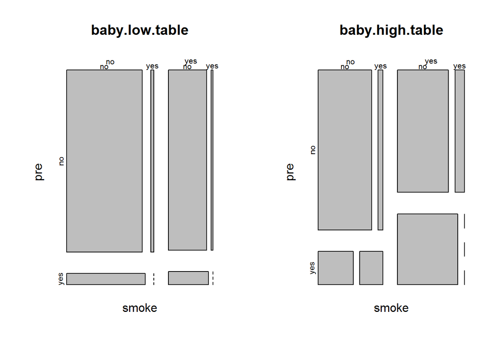

Given a baby is born with a low birth weight, pregnant women who do not smoke and do not have hypertension, are less likely to have a history of pre-mature labor. Given a baby is born with a low birth weight, pregnant women who do not smoke and have hypertension are less likely to have a history of pre-mature labor

Given that a baby was not born with a low birth weight, pregnant women who do not smoke and do not have hypertension, are less likely to have a history of pre-mature labor. However, if a pregnant women does have hypertension and does not smoke, there is a higher chance that they will have a history of pre-mature labor.

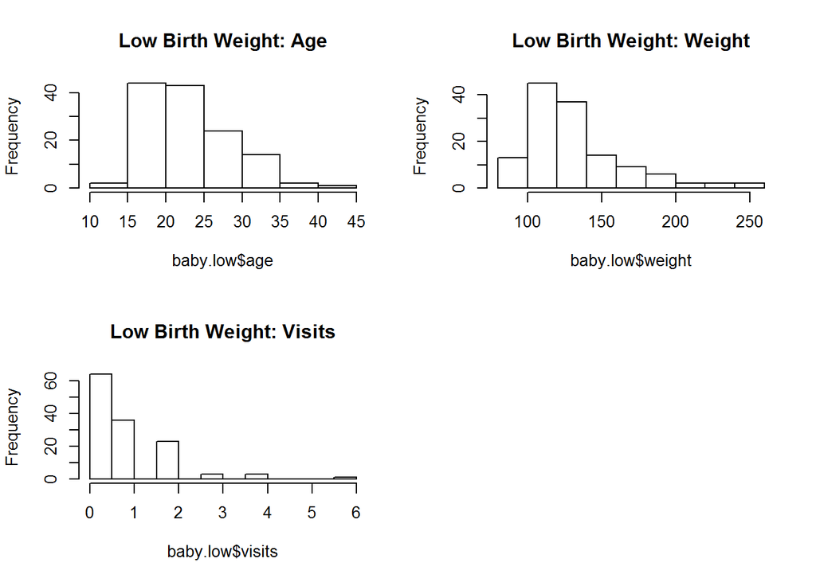

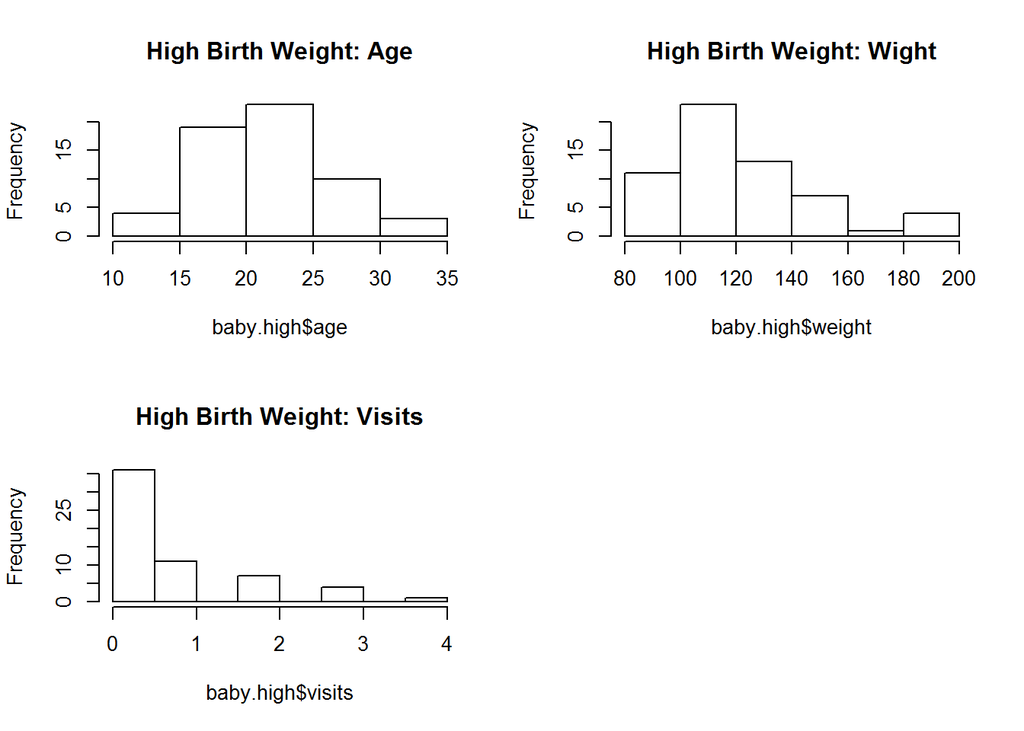

## Analysis

### Diagnostics

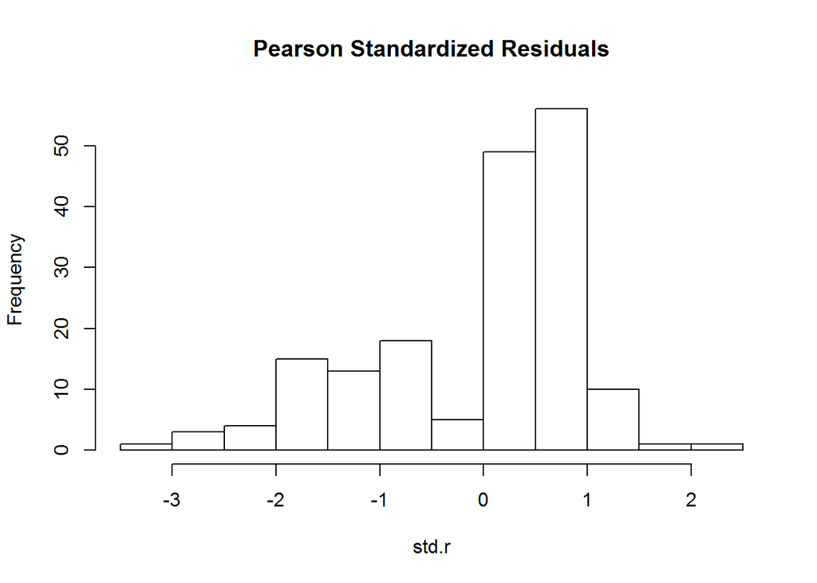

From the histogram plot above, we can see that not all of our residuals are normal. We can see that some residuals are smaller than -3 and they may be outliers/influential points.

We calcualted the change in Pearson Chi-Squared for each observation. When the change is large, it generally means that the observation we added may be an outlier or an influential point. We found five of changes in Pearson’s Chi-Squared that were larger than 6, our cutoff value:

```
##    (Intercept) age weight smokeyes preyes hypyes    dChisq
## 1:           1  29    130        0      0      0  6.248893
## 2:           1  27    150        0      0      0  7.632683
## 3:           1  23    187        1      0      0  6.631935
## 4:           1  26    190        1      0      0  8.318037
## 5:           1  21    200        0      0      0 12.082077
```

### Predictive power

Our predictive power based on proportional redunction in squared error is 0.171218.

### Goodness of fit

The AUC is 0.734. We are 95% confident that the AUC is between 0.6554 and 0.8127.

### Error matrix

Our error matrix is:

```
##       preds
## actual   0   1
##      0  21  38
##      1  10 120
```

Our error rate is 25.39683%.

### Prediction

The probability that a women aged 29, who weighs 157 pounds, does not smoke, does not have a history of pre-mature labor, does not have hypertension, and had 20 visits has a low weight baby is 0.9049528.

## Interpretation

Since the AUC is between 0.6554 and 0.8127 with 95% confidence and the lower bound is above 0.50 , we can say we significant increased our preditive power. Our calculation for AUC is 0.734, which means that our model has fit the data well.

Since we have an error rate of 25.39683%, we can say that our model does mot predict well.

## Conclusion

We found that the the variables that most influence a low birth weight are the mother’s age and weight, whether or not she smoked during the pregnancy, her history of pre-mature labor, and history of hypertension. Our model fits the data well, but it does not nescessarily predict well.

## Code Appendix

```r
library(vcd)
library(grid)
library(nnet)

student = read.csv("student.csv")

vplayout = function(x, y) viewport(layout.pos.row = x, layout.pos.col = y)

high_ses = student[student$ses=="high",]
high_ses_table = table(high_ses[,c("gender", "schtyp", "honors")])
mid_ses = student[student$ses=="middle",]
mid_ses_table = table(mid_ses[,c("gender", "schtyp", "honors")])
low_ses = student[student$ses=="low",]
low_ses_table = table(low_ses[,c("gender", "schtyp", "honors")])
mosaicplot(high_ses_table)
mosaicplot(mid_ses_table)
mosaicplot(low_ses_table)
par(mfrow=c(2,2))

hist(low_ses$math, main = "Low SES: Math")
hist(low_ses$read, main = "Low SES: Read")
hist(low_ses$science, main = "Low SES: Science")
hist(low_ses$write, main = "Low SES: Write")
par(mfrow=c(2,2))

hist(mid_ses$math, main = "Middle SES: Math")
hist(mid_ses$read, main = "Middle SES: Read")
hist(mid_ses$science, main = "Middle SES: Science")
hist(mid_ses$write, main = "Middle SES: Write")
par(mfrow=c(2,2))

hist(high_ses$math, main = "High SES: Math")
hist(high_ses$read, main = "High SES: Read")
hist(high_ses$science, main = "High SES: Science")
hist(high_ses$write, main = "High SES: Write")
full.model = multinom(ses ~.,data = student,trace = FALSE)
null.model = multinom(ses ~ 1,data = student,trace = FALSE)
best.BF.AIC = step(full.model,scope = list(lower = null.model, upper = full.model),direction = "both", criterion = "AIC", trace = FALSE)
summary(best.BF.AIC)
best.model = multinom(ses ~ gender + schtyp + read + honors, data = student, trace = FALSE, family=mul)
summary(best.model)$coefficients
test.data = student[,c("gender", "schtyp", "read", "write", "math", "science", "honors", "ses")]
split.data = split(test.data, test.data$ses)

lowvshigh = rbind(split.data[[2]], split.data[[1]])
medvshigh = rbind(split.data[[3]], split.data[[1]])
lh.model = glm(factor(ses) ~ gender + schtyp + read + honors, data = lowvshigh,
               family = binomial(logit))
mh.model = glm(factor(ses) ~ gender + schtyp + read + honors, data = medvshigh,
               family = binomial(logit))
library(LogisticDx)
good.stuff = dx(lh.model)
std.r = good.stuff$sPr #Standardized residuals (Pearson)
hist(std.r, main = "Pearson Standardized Residuals")
change.pearson = good.stuff$dChisq #Change in pearson X^2 for each observation
cutoff.pearson = 6
good.stuff[change.pearson > cutoff.pearson,c(1:5,15)] #what observations they were
good.stuff.mh = dx(mh.model)
std.r.mh = good.stuff.mh$sPr #Standardized residuals (Pearson)
hist(std.r.mh, main = "Pearson Standardized Residuals")
change.pearson.mh = good.stuff.mh$dChisq #Change in pearson X^2 for each observation
good.stuff.mh[change.pearson.mh > cutoff.pearson,c(1:5,15)]
r = cor(lh.model$y,lh.model$fitted.values)
prop.red = 1- sum((lh.model$y -lh.model$fitted.values)^2)/sum((lh.model$y - mean(lh.model$y))^2)
prop.red
r = cor(mh.model$y,mh.model$fitted.values)
prop.red = 1- sum((mh.model$y -mh.model$fitted.values)^2)/sum((mh.model$y - mean(mh.model$y))^2)
prop.red
library(pROC)
the.roc = roc(lh.model$y, lh.model$fitted.values,auc = TRUE, ci = TRUE,plot=TRUE, legacy.axes = TRUE)
auc(the.roc)
ci(the.roc)
the.roc = roc(mh.model$y, mh.model$fitted.values,auc = TRUE, ci = TRUE,plot=TRUE, legacy.axes = TRUE)
auc(the.roc)
ci(the.roc)
fits=predict(best.model) # The fits
error=table(actual=student$ses,preds = predict(best.model)) #Error matrix
percent.correct = sum(diag(error))/sum(error)
percent.incorrect = 1-percent.correct
error
predict.values = data.frame(gender=c("female"), schtyp=c("private"), read=60, write=60, math=60, science=60, honors=c("no"))
predict(best.model, predict.values, type = "probs")
baby = read.csv("baby.csv")

baby.low = baby[baby$low==1,]
baby.high = baby[baby$low==0,]
baby.low.table = table(baby.low[,c("smoke", "pre", "hyp")])
baby.high.table = table(baby.high[,c("smoke", "pre", "hyp")])
par(mfrow=c(1,2))

mosaicplot(baby.low.table)
mosaicplot(baby.high.table)
par(mfrow=c(2,2))

hist(baby.low$age, main = "Low Birth Weight: Age")
hist(baby.low$weight, main = "Low Birth Weight: Weight")
hist(baby.low$visits, main = "Low Birth Weight: Visits")
par(mfrow=c(2,2))

hist(baby.high$age, main = "High Birth Weight: Age")
hist(baby.high$weight, main = "High Birth Weight: Wight")
hist(baby.high$visits, main = "High Birth Weight: Visits")
full.model = glm(low ~. , data = baby, family = binomial(link=logit))

#Backward AIC because we want to predict later
empty.model = glm(low ~ 1, data = baby, family = binomial(link=logit))
best.backward.AIC = step(full.model,scope = list(lower = empty.model, upper = full.model),direction = "backward", criterion = "AIC", trace = FALSE)
best.backward.AIC$formula

best.model = best.backward.AIC
library(LogisticDx)
good.stuff = dx(best.model)
pear.r = good.stuff$Pr #Pearsons Residuals
deviance.r = good.stuff$dr #Deviance Residuals
std.r = good.stuff$sPr #Standardized residuals (Pearson)
hist(std.r, main = "Pearson Standardized Residuals")
change.pearson = good.stuff$dChisq #Change in pearson X^2 for each observation
cutoff.pearson = 6
good.stuff[change.pearson > cutoff.pearson,c(1:6,16)]
r = cor(best.model$y,best.model$fitted.values)
prop.red = 1- sum((best.model$y -best.model$fitted.values)^2)/sum((best.model$y - mean(best.model$y))^2)
prop.red
library(pROC)
the.roc = roc(best.model$y, best.model$fitted.values,auc = TRUE, ci = TRUE,plot=TRUE, legacy.axes = TRUE)
auc(the.roc)
ci(the.roc)
fits=predict(best.model, type="response") # The fits
fits = ifelse(fits>0.5,1,0)
test.data = table(actual=baby$low, preds = fits)
error = test.data
percent.correct = sum(diag(error))/sum(error)
percent.incorrect = 1-percent.correct
percent.incorrect
error
predict(best.model,newdata = data.frame(age = 29, weight = 157, smoke = "no",
                                         pre = "no", hyp = "no", visits = 20, low = 1),
        type = "response")
```